# Add HRL Habitat Data

Liz Stebbins (FlowWest)

2025-02-17

# Overview

Habitat and flow commitments made under the Healthy Rivers and Landscapes (HRL) program were included as inputs to the R2R modeling framework for the following watersheds:

- American River
- Feather River
- Mokelumne River
- Yuba River
- Tuolumne River

Staff from the Tuolumne River and Yuba River provided flow-to-suitable area relationships representing anticipated effects of the HRL commitments. These watersheds developed methodology to scale existing flow-to-suitable habitat relationships based on existing and proposed habitat projects. Documentation for the Tuolumne River methodology is available [here](https://va-hrl-docs.s3.us-east-1.amazonaws.com/tuolumne/Tuolumne+River+VA+Habitat+Modeling+for+SBR+final+revision+20240802.pdf) and for the Yuba River methodology [here](https://va-hrl-docs.s3.us-east-1.amazonaws.com/yuba/Summary+of+LYR+Hydraulic+Modeling+Methodology_7-1-2024.docx).

For the Mokelumne, American, and Feather Rivers, R2R used the flow-to-suitable area relationships provided for the [Scientific Basis Report (SBR), Section 6](https://www.waterboards.ca.gov/waterrights/water_issues/programs/bay_delta/docs/2023/staff-report/app-g2.pdf) to ensure consistency across the basin.

# Methods

The following workflow was used to incorporate these relationships into the R2R habitat model framework:

1. Read in the flow-to-suitable area relationship used in the SBR.
2. Functionalize the relationship using interpolation with flow as the predictive variable and suitable habitat as the response variable.
3. Generate estimated habitat using flows from the HRL CalSim3 run for the model years (`1980-2000`).

# Read and functionalize flow-to-area curves

## American River

### HRL flow-to-habitat relationship

Instream and floodplain rearing habitat were provided. They are the same as those used in the SBR.

**Data Source:** FlowWest coordinated with representatives for the American River to determine the best scientific information available to quantify existing suitable habitat, and to describe the VA non-flow habitat as suitable area that varies with flow. Habitat data were provided to R2R for use in accounting for planned habitat projects by Erica Bishop and Chris Hammersmark. Data provided represented the HRL commitments based on flow-to-habitat relationships borne out by recent EIP designs and constructed projects for the subject habitat type.

[output not shown]

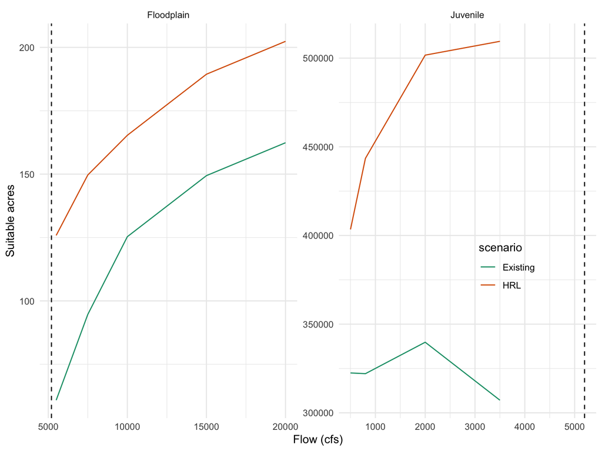

## Feather River

### HRL flow-to-habitat relationship

Spawning and instream rearing actions are only for the LFC.

**Data Source:** Data came from the FERC relicensing spawning WUA/RSI and were provided for the SBR by Jason Kindopp.

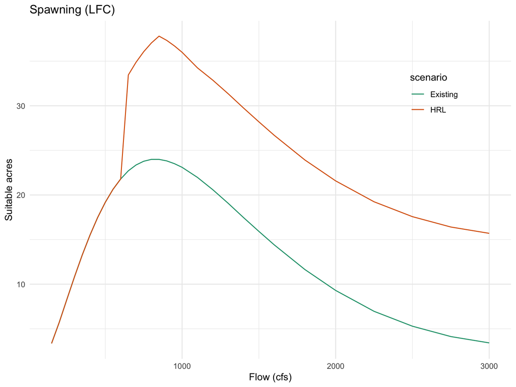

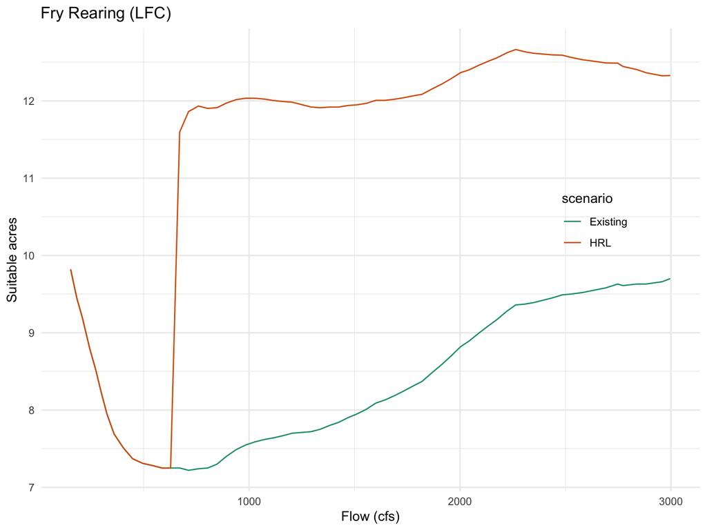

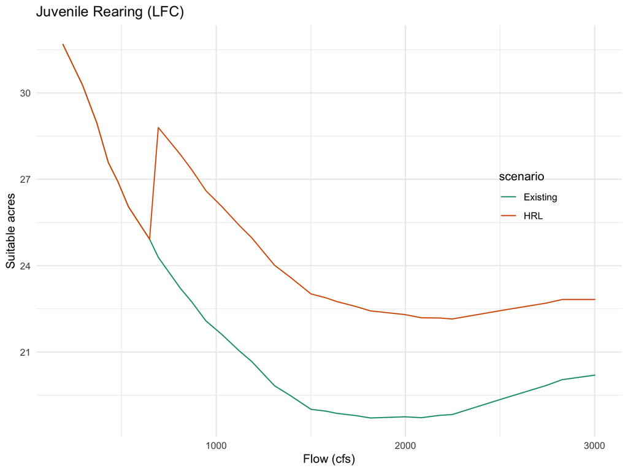

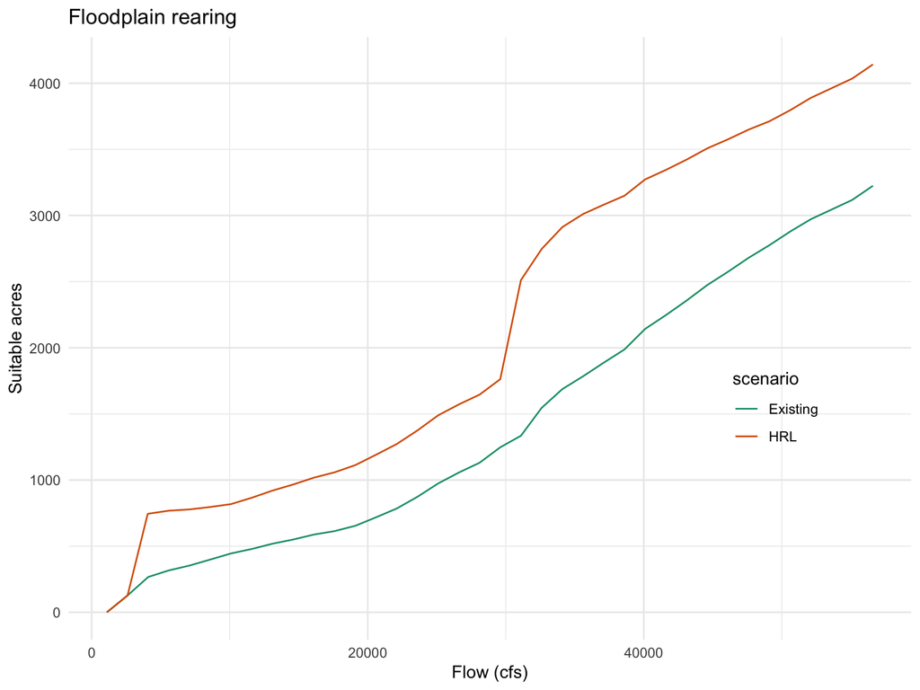

| Watershed | Location | Scenario | Flow (cfs) | Habitat type | Suitable acres |
| --- | --- | --- | --- | --- | --- |
| Feather River | LFC | Existing | 150 | Spawning | 3.36 |
| Feather River | LFC | Existing | 200 | Spawning | 5.72 |
| Feather River | LFC | Existing | 250 | Spawning | 8.31 |
| Feather River | LFC | Existing | 300 | Spawning | 10.86 |
| Feather River | LFC | Existing | 350 | Spawning | 13.28 |
| Feather River | LFC | Existing | 400 | Spawning | 15.49 |

## Mokelumne River

### HRL flow-to-habitat relationship

**Data Source:** Data were provided by Robyn Bilski for the SBR.

| Flow (cfs) | Habitat type | Suitable acres | Scenario |
| --- | --- | --- | --- |
| 105 | Spawning | 8 | HRL |
| 105 | Juvenile | 209 | HRL |
| 105 | Fry | 189 | HRL |
| 140 | Spawning | 10 | HRL |
| 140 | Juvenile | 202 | HRL |
| 140 | Fry | 179 | HRL |

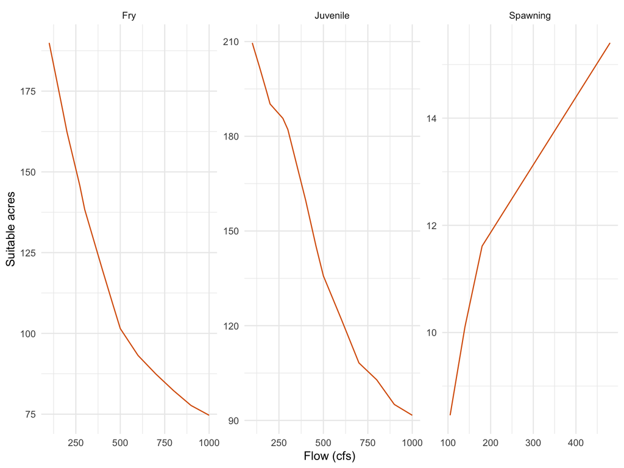

# Generate estimated habitat using flow

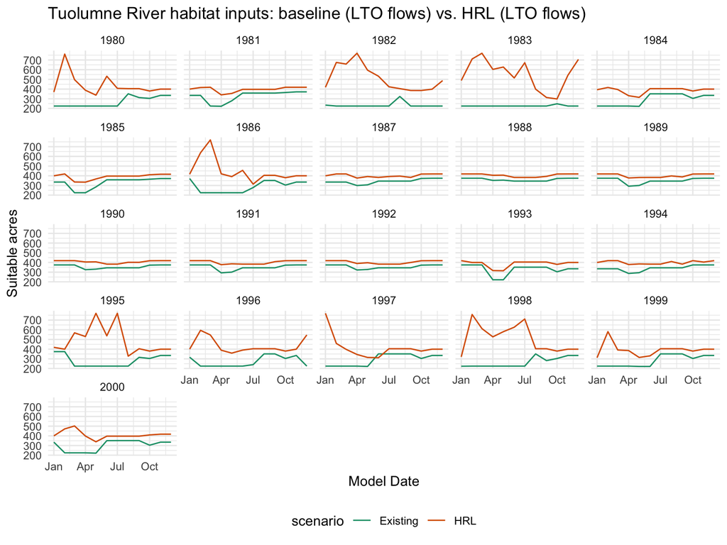

# Other HRL commitments

We modeled additional commitments that were listed in the [Memorandum of Understanding, Appendix 2](https://resources.ca.gov/-/media/CNRA-Website/Files/NewsRoom/email-items/VoluntaryAgreementMOUTermSheet20220329_SIGNED-20220811.pdf):

| Area | Total acres |
| --- | --- |
| Sutter Bypass, Butte Sink, and Colusa Basin | 20,000 (floodplain) |
| Sutter Bypass, Butte Sink, and Colusa Basin | 20,000 (fish food production) |

## Sacramento Floodplain improvements (Sutter, Colusa, Butte Sink)

- 20,000 acres were added to the Sutter Bypass watershed **after** the existing flow-to-area relationship was modeled using HRL flows.
- From December 1st to March 15th, Sutter Bypass will be assumed to have 20,000 acres of suitable habitat in each year.

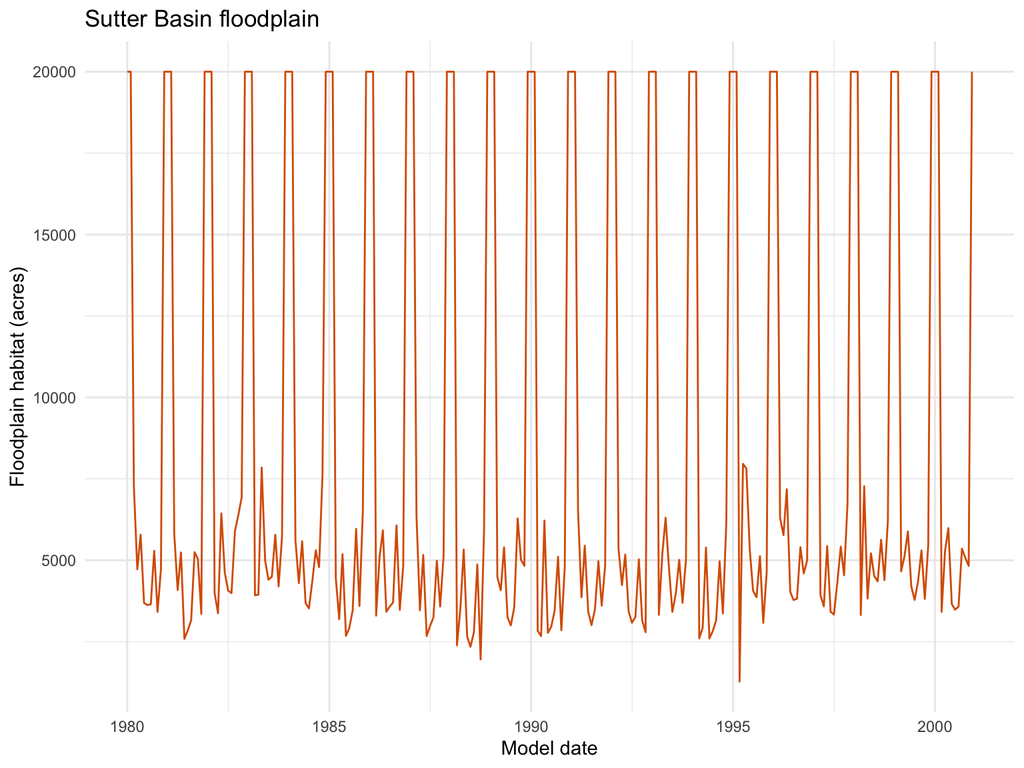

## 20,000 acres fish food production

- To model the effects of 20,000 acres of fish food production, we calculated the available acreage for dry side floodplain for Sutter and Colusa basins using these data
- We then calculated the proportion of the committed 20,000 acres those acreages provide, and use that proportion to scale instream habitat for those watersheds.
- This will occur in every year from Jan 1st to Feb 28th

| Watershed | Dry | Wet | Proportion |
| --- | --- | --- | --- |
| Colusa Basin | 576,753 | 163 | 0.035 |
| Sutter Basin | 263,652 | 23,321 | 0.076 |

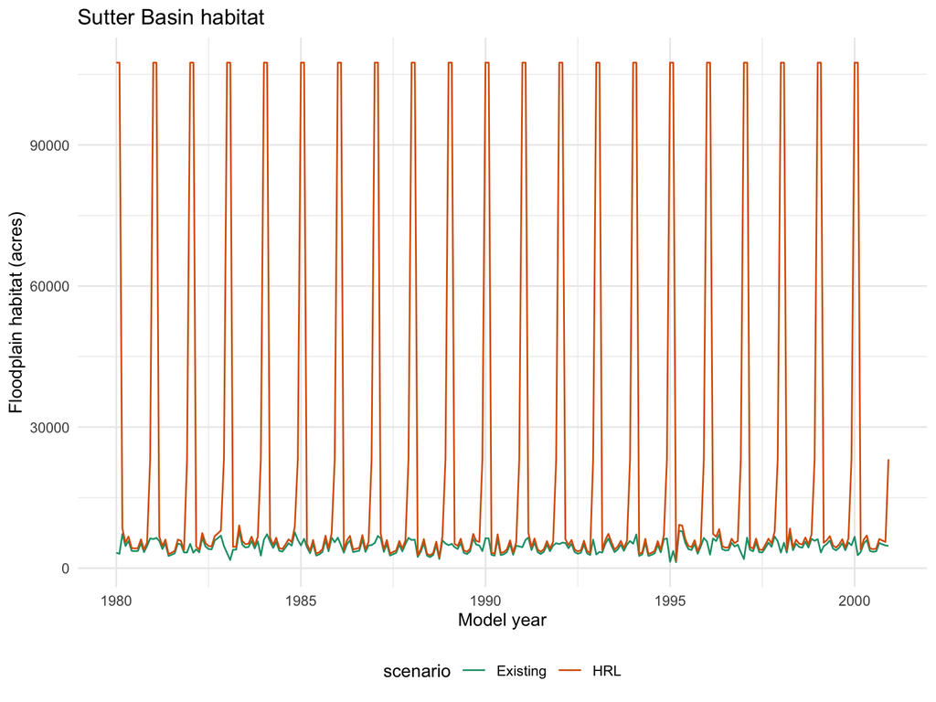

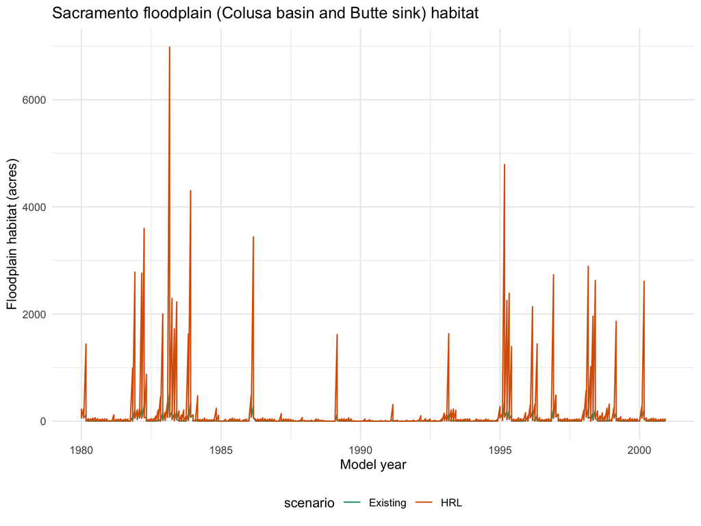

[output not shown]